# Intro to Data Analysis using R & Apache Spark

Buu Thong Tran

January 13, 2017

The original article of this tutorial can be found [here](http://spark.rstudio.com/index.html)

## Installation

You can install the sparklyr package from CRAN as follows:

```r
install.packages("sparklyr", repos="http://cran.rstudio.com/")
```

You should also install a local version of Spark for development purposes:

```r
library(sparklyr)
spark_install(version = "1.6.2")
```

To upgrade to the latest version of sparklyr, run the following command and restart your r session:

```r
library(dplyr)
devtools::install_github("rstudio/sparklyr")
```

## Connecting to Spark

You can connect to both local instances of Spark as well as remote Spark clusters. Here we’ll connect to a local instance of Spark via the spark_connect function:

```r
library(sparklyr)
sc <- spark_connect(master = "local")
```

The returned Spark connection (sc) provides a remote dplyr data source to the Spark cluster.

## Using dplyr

We can use all of the available dplyr verbs against the tables within the cluster.

We’ll start by copying some datasets from R into the Spark cluster (note that you may need to install the nycflights13 and Lahman packages in order to execute this code):

```r
install.packages(c("nycflights13", "Lahman"), repos="http://cran.rstudio.com/")
library(dplyr)
iris_tbl <- copy_to(sc, iris)
flights_tbl <- copy_to(sc, nycflights13::flights, "flights")
batting_tbl <- copy_to(sc, Lahman::Batting, "batting")
src_tbls(sc)
```

```
## [1] "batting" "flights" "iris"
```

To start with here’s a simple filtering example:

```r
# filter by departure delay and print the first few records
flights_tbl %>% filter(dep_delay == 2)
```

```
## Source:   query [6,233 x 19]
## Database: spark connection master=local[4] app=sparklyr local=TRUE
##
##     year month   day dep_time sched_dep_time dep_delay arr_time
##    <int> <int> <int>    <int>          <int>     <dbl>    <int>
## 1   2013     1     1      517            515         2      830
## 2   2013     1     1      542            540         2      923
## 3   2013     1     1      702            700         2     1058
## 4   2013     1     1      715            713         2      911
## 5   2013     1     1      752            750         2     1025
## 6   2013     1     1      917            915         2     1206
## 7   2013     1     1      932            930         2     1219
## 8   2013     1     1     1028           1026         2     1350
## 9   2013     1     1     1042           1040         2     1325
## 10  2013     1     1     1231           1229         2     1523
## # ... with 6,223 more rows, and 12 more variables: sched_arr_time <int>,
## #   arr_delay <dbl>, carrier <chr>, flight <int>, tailnum <chr>,
## #   origin <chr>, dest <chr>, air_time <dbl>, distance <dbl>, hour <dbl>,
## #   minute <dbl>, time_hour <dbl>
```

[Introduction to dplyr](https://cran.r-project.org/package=dplyr) provides additional dplyr examples you can try. For example, consider the last example from the tutorial which plots data on flight delays:

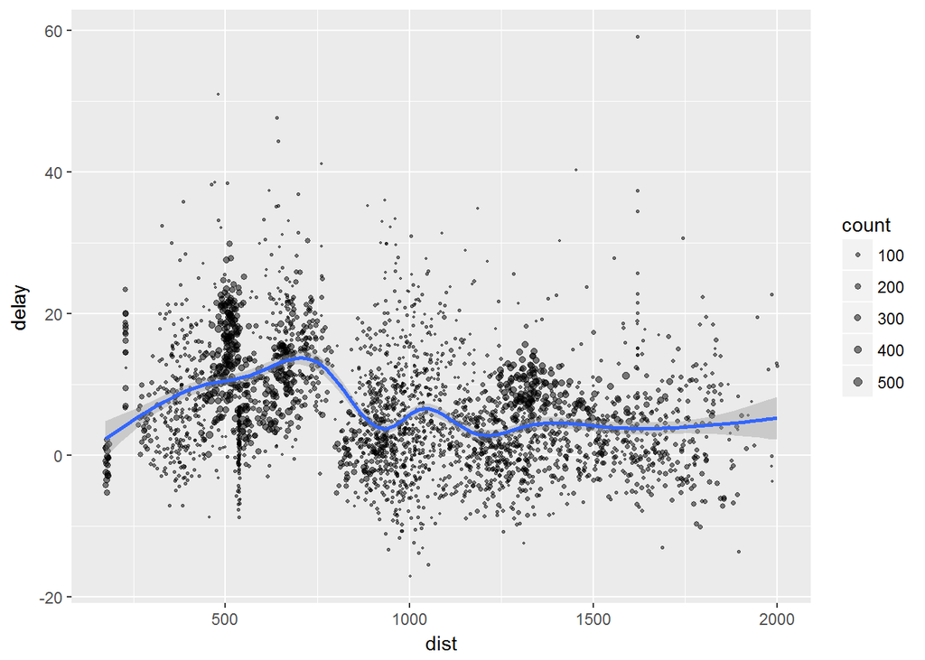

```r
delay <- flights_tbl %>%
  group_by(tailnum) %>%
  summarise(count = n(), dist = mean(distance), delay = mean(arr_delay)) %>%
  filter(count > 20, dist < 2000, !is.na(delay)) %>%
  collect

# plot delays
library(ggplot2)
ggplot(delay, aes(dist, delay)) +
  geom_point(aes(size = count), alpha = 1/2) +
  geom_smooth() +
  scale_size_area(max_size = 2)
```

### Window Functions

dplyr [window functions](https://cran.r-project.org/package=dplyr) are also supported, for example:

```r
batting_tbl %>%
  select(playerID, yearID, teamID, G, AB:H) %>%
  arrange(playerID, yearID, teamID) %>%
  group_by(playerID) %>%
  filter(min_rank(desc(H)) <= 2 & H > 0)
```

```
## Source:   query [2.562e+04 x 7]
## Database: spark connection master=local[4] app=sparklyr local=TRUE
## Groups: playerID
##
##     playerID yearID teamID     G    AB     R     H
##        <chr>  <int>  <chr> <int> <int> <int> <int>
## 1   abadan01   2003    BOS     9    17     1     2
## 2  abbated01   1905    BSN   153   610    70   170
## 3  abbated01   1904    BSN   154   579    76   148
## 4  abbotda01   1890    TL2     3     7     0     1
## 5  abbotod01   1910    SLN    22    70     2    13
## 6  abbotpa01   2000    SEA    35     5     1     2
## 7  abbotpa01   2004    PHI    10    11     1     2
## 8   aberal01   1954    DET    32    39     3     5
## 9   aberal01   1953    DET    17    23     2     3
## 10  aberal01   1956    DET    42    10     0     3
## # ... with 2.561e+04 more rows
```

For additional documentation on using [dplyr](http://spark.rstudio.com/dplyr.html) with Spark see the dplyr section of the sparklyr website.

## Using SQL

It’s also possible to execute SQL queries directly against tables within a Spark cluster. The spark_connection object implements a DBI interface for Spark, so you can use dbGetQuery to execute SQL and return the result as an R data frame:

```r
library(DBI)
iris_preview <- dbGetQuery(sc, "SELECT * FROM iris WHERE Species = 'virginica' ORDER BY Sepal_Length LIMIT 10")
iris_preview
```

```
##    Sepal_Length Sepal_Width Petal_Length Petal_Width   Species
## 1           4.9         2.5          4.5         1.7 virginica
## 2           5.6         2.8          4.9         2.0 virginica
## 3           5.7         2.5          5.0         2.0 virginica
## 4           5.8         2.7          5.1         1.9 virginica
## 5           5.8         2.7          5.1         1.9 virginica
## 6           5.8         2.8          5.1         2.4 virginica
## 7           5.9         3.0          5.1         1.8 virginica
## 8           6.0         2.2          5.0         1.5 virginica
## 9           6.0         3.0          4.8         1.8 virginica
## 10          6.1         3.0          4.9         1.8 virginica
```

## Machine Learning

You can orchestrate machine learning algorithms in a Spark cluster via the [machine learning](http://spark.apache.org/docs/latest/mllib-guide.html) functions within **sparklyr**. These functions connect to a set of high-level APIs built on top of DataFrames that help you create and tune machine learning workflows.

Here’s an example where we use [ml_linear_regression](http://spark.rstudio.com/reference/sparklyr/latest/ml_linear_regression.html) to fit a linear regression model. We’ll use the built-in `mtcars` dataset, and see if we can predict a car’s fuel consumption (`mpg`) based on its weight (`wt`), and the number of cylinders the engine contains (`cyl`). We’ll assume in each case that the relationship between `mpg` and each of our features is linear.

```r
# copy mtcars into spark
mtcars_tbl <- copy_to(sc, mtcars)

# transform our data set, and then partition into 'training', 'test'
partitions <- mtcars_tbl %>%
  filter(hp >= 100) %>%
  mutate(cyl8 = cyl == 8) %>%
  sdf_partition(training = 0.5, test = 0.5, seed = 1099)

# fit a linear model to the training dataset
fit <- partitions$training %>%
  ml_linear_regression(response = "mpg", features = c("wt", "cyl"))
```

```r
fit
```

```
## Call: ml_linear_regression(., response = "mpg", features = c("wt", "cyl"))
##
## Coefficients:
## (Intercept)          wt         cyl
##   37.066699   -2.309504   -1.639546
```

For linear regression models produced by Spark, we can use summary() to learn a bit more about the quality of our fit, and the statistical significance of each of our predictors.

```r
summary(fit)
```

```
## Call: ml_linear_regression(., response = "mpg", features = c("wt", "cyl"))
##
## Deviance Residuals::
##     Min      1Q  Median      3Q     Max
## -2.6881 -1.0507 -0.4420  0.4757  3.3858
##
## Coefficients:
##             Estimate Std. Error t value  Pr(>|t|)
## (Intercept) 37.06670    2.76494 13.4059 2.981e-07 ***
## wt          -2.30950    0.84748 -2.7252   0.02341 *
## cyl         -1.63955    0.58635 -2.7962   0.02084 *
## ---
## Signif. codes:  0 '***' 0.001 '**' 0.01 '*' 0.05 '.' 0.1 ' ' 1
##
## R-Squared: 0.8665
## Root Mean Squared Error: 1.799
```

Spark machine learning supports a wide array of algorithms and feature transformations and as illustrated above it’s easy to chain these functions together with dplyr pipelines. To learn more, see the [machine learning](http://spark.rstudio.com/mllib.html) section.

## Reading and Writing Data

You can read and write data in CSV, JSON, and Parquet formats. Data can be stored in HDFS, S3, or on the lcoal filesystem of cluster nodes.

```r
temp_csv <- tempfile(fileext = ".csv")
temp_parquet <- tempfile(fileext = ".parquet")
temp_json <- tempfile(fileext = ".json")

spark_write_csv(iris_tbl, temp_csv)
iris_csv_tbl <- spark_read_csv(sc, "iris_csv", temp_csv)

spark_write_parquet(iris_tbl, temp_parquet)
iris_parquet_tbl <- spark_read_parquet(sc, "iris_parquet", temp_parquet)

spark_write_json(iris_tbl, temp_json)
iris_json_tbl <- spark_read_json(sc, "iris_json", temp_json)

src_tbls(sc)
```

```
## [1] "batting"      "flights"      "iris"         "iris_csv"
## [5] "iris_json"    "iris_parquet" "mtcars"
```

## Extensions

The facilities used internally by sparklyr for its dplyr and machine learning interfaces are available to extension packages. Since Spark is a general purpose cluster computing system there are many potential applications for extensions (e.g. interfaces to custom machine learning pipelines, interfaces to 3rd party Spark packages, etc.).

Here’s a simple example that wraps a Spark text file line counting function with an R function:

```r
# write a CSV
tempfile <- tempfile(fileext = ".csv")
write.csv(nycflights13::flights, tempfile, row.names = FALSE, na = "")

# define an R interface to Spark line counting
count_lines <- function(sc, path) {
  spark_context(sc) %>%
    invoke("textFile", path, 1L) %>%
      invoke("count")
}

# call spark to count the lines of the CSV
count_lines(sc, tempfile)
```

```
## [1] 336777
```

To learn more about creating extensions see the Extensions section of the sparklyr website.

## Table Utilities

You can cache a table into memory with:

```r
tbl_cache(sc, "batting")
```

and unload from memory using:

```r
tbl_uncache(sc, "batting")
```

## Connection Utilities

You can view the Spark web console using the spark_web function:

```r
spark_web(sc)
```

You can show the log using the spark_log function:

```r
spark_log(sc, n = 10)
```

```
## 17/01/13 23:03:50 INFO Executor: Running task 0.0 in stage 95.0 (TID 156)
## 17/01/13 23:03:50 INFO ShuffleBlockFetcherIterator: Getting 2 non-empty blocks out of 2 blocks
## 17/01/13 23:03:50 INFO ShuffleBlockFetcherIterator: Started 0 remote fetches in 0 ms
## 17/01/13 23:03:50 INFO Executor: Finished task 0.0 in stage 95.0 (TID 156). 1830 bytes result sent to driver
## 17/01/13 23:03:50 INFO DAGScheduler: ResultStage 95 (collect at utils.scala:195) finished in 0.009 s
## 17/01/13 23:03:50 INFO DAGScheduler: Job 63 finished: collect at utils.scala:195, took 0.036041 s
## 17/01/13 23:03:50 INFO TaskSetManager: Finished task 0.0 in stage 95.0 (TID 156) in 8 ms on localhost (1/1)
## 17/01/13 23:03:50 INFO TaskSchedulerImpl: Removed TaskSet 95.0, whose tasks have all completed, from pool
## 17/01/13 23:03:51 INFO MapPartitionsRDD: Removing RDD 70 from persistence list
## 17/01/13 23:03:51 INFO BlockManager: Removing RDD 70
```

Finally, we disconnect from Spark:

```r
spark_disconnect(sc)
```